# INTRODUCTION

After gathering,accessing and cleaning the next step to take is visualisation the folowing visualisations were created to answer some vital questions such as:

- What percentage of dog stages were assigned values in the dataset?
- Then among the dog stage values which values appeared the most?
- What type of relationship does the favorite count(likes) and the retweets have?
- Which source of tweets was the most used in the WeRateDogs archive?
- From which source were tweets liked the most?
- ON AVERAGE ;
- Which stage of dogs had the highest ratings?
- Which source of tweets had the most likes?
- Which source of tweets had the most retweets?

```
- Using matplotlib and pandas i created the following visualisations:
```

- The pie chart below that shows 83% of the entries of the records didnt specify a dog stage for the dogs and about 17%(16.8%) had a specified stage

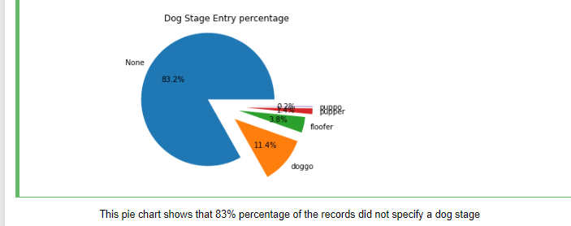

- But from the one with non null entries I deduced from the pie chart that doggo was the most common type of dog among the dogs rated in the weratedogs archive with a percentage of 67.9% followed by floofer(22.7%) then pupper(8.2%) puppo(1.1%)

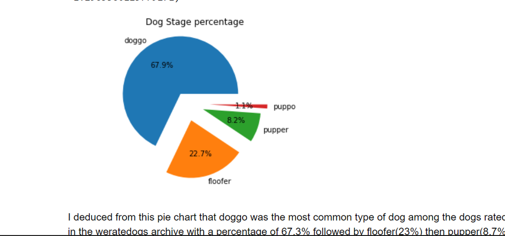

- I also created a scatterplot which I deduced as the favorites(likes)increase the retweets increase hence concluding that there is a linear relationship between retweet count and favorite count which hints at positive correlation

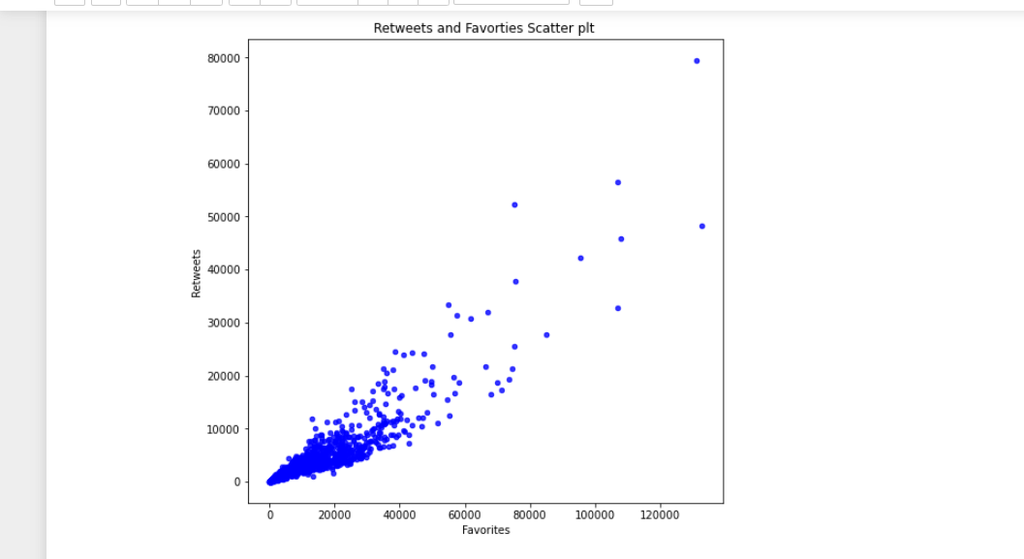

- I created a pie chart to depict the percentage of the source of tweets in the weratedogs archive and I came to the conlusion that Twitter for iphone was the most common source of tweets in the WeRateDogs TweetDeck was the least used source of tweets

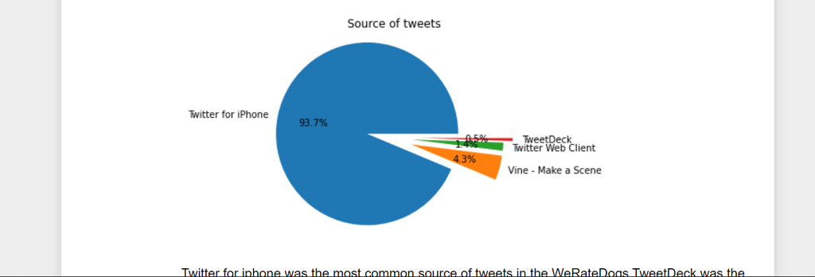

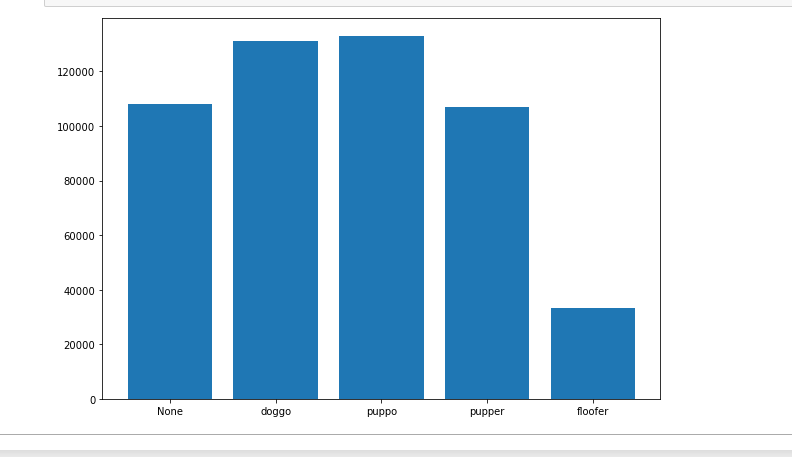

- I created 3 pivot tables and came up with the following conclusions :
- the first one shows the source 'Twitter for iphone' is also the source with the most amount of likes on average(favourite_count)
- the second one shows that the source 'Vine-Make a scene' is the source with the most amount of retweets on average
- the third one showed doggo had the highest ratings on average while puppo had the least average ratings among the specified entries

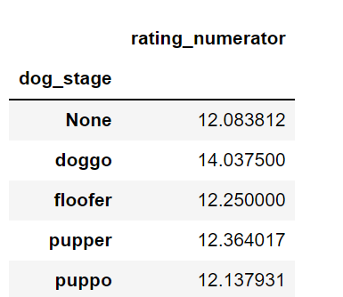

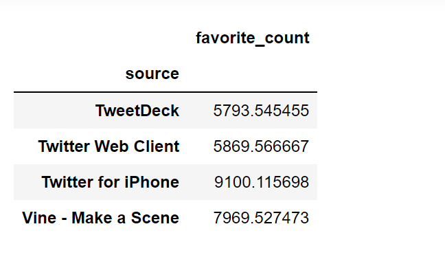

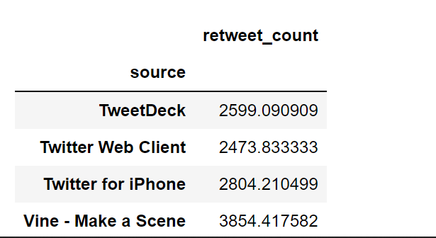

# CONCLUSION

- The visualisations created were designed to answer the above mentioned questions such as:
- What percentage of dog stages were assigned values in the dataset? 16.8% of dogs were given specified dog stages
- Then among the dog stage values which values appeared the most? Doggo(67.9%)
- What type of relationship does the favorite count(likes) and the retweets have? The relationship between favorite count and the retweets is linear(positive correlation)
- Which source of tweets was the most used in the WeRateDogs archive? Twitter for iphone(93.7%)
- Which dog stage had the most liked tweets? The puppo stage had the most liked tweets
- On average, which stage of dogs had the highest ratings? doggo had the highest with a mean rating of 14.04/10
- On average, which source of tweets had the most likes? Twitter for iphone had the most likes with a value of 9100.11 likes per tweet
- On average, which source of tweets had the most retweets? Vine-Make a scene had the most with a value of 3854.42 retweets per tweet
- With these answers and values;
- users can easily decide which stage of dogs to purchase and from my findings that should be a dog in the doggo stage since they have a high average rating of 14.04/10
- also sellers can decide which platform can be used to advertise their dogs on Twitter that should be the Twitter for iphone because a tweet from there will have a high amount of likes and it is the most used in the WeRateDogs archive